# Task 1: Principal Component Analysis

Grace Bianchi

2023-03-01

```r
knitr::opts_chunk$set(echo = TRUE, warning = FALSE, message = FALSE)

library(tidyverse)
library(ggfortify) # For PCA biplot
```

**Introduction** This code wrangles and explores multivariate country dataset using principal component analysis. The dataset includes environmental variables such as temperature, elevation, and canopy cover for 243 countries, in which most of the data was “derived by calculating the mean for each country at a reduction scale of about 10km.” This data was compiled and provided by @zander_venter on Kaggle, where all data was acquired through Google Earth Engine, where publicly available remote sensing datasets have been uploaded.

**Source:** Google Earth Engine (https://earthengine.google.com/),

### Data Exploration

Read in and wrangle the data. The quarterly data was removed since annual estimates are provided. The variable included in the principal component analysis are accessibility to cities, elevation, cropland cover, tree canopy cover, mean annual rain, mean annual temperature, annual temperature range, temperature seasonality, wind, and cloudiness. After removing NA values, 188 countries remain for further analysis.

```r
### read in the data
env_vars_data <- read_csv("world_env_vars.csv") %>%
  janitor::clean_names()

climate_subset <- env_vars_data %>%
  # summarize(across(everything(), ~sum(is.na(.))))  number of NAs in each col
  select(country, accessibility_to_cities, elevation, cropland_cover, tree_canopy_cover, rain_mean_annual, temp_mean_annual, temp_annual_range, temp_seasonality, wind, cloudiness) %>%
  drop_na()
```

### Principal Component Analysis

```r
env_pca <- climate_subset %>%
  select(where(is.numeric)) %>% # select only numeric columns for PCA
  prcomp(scale = TRUE) # pca

#summary(env_pca)
# See the loadings (weighting for each principal component)
#env_pca$rotation
```

Principal component 1 captures 41% of variance, followed by principal component 2 which captures 17% variance, and 95% of the variance is captured by the first six principal components.

#### PCA BiPlot

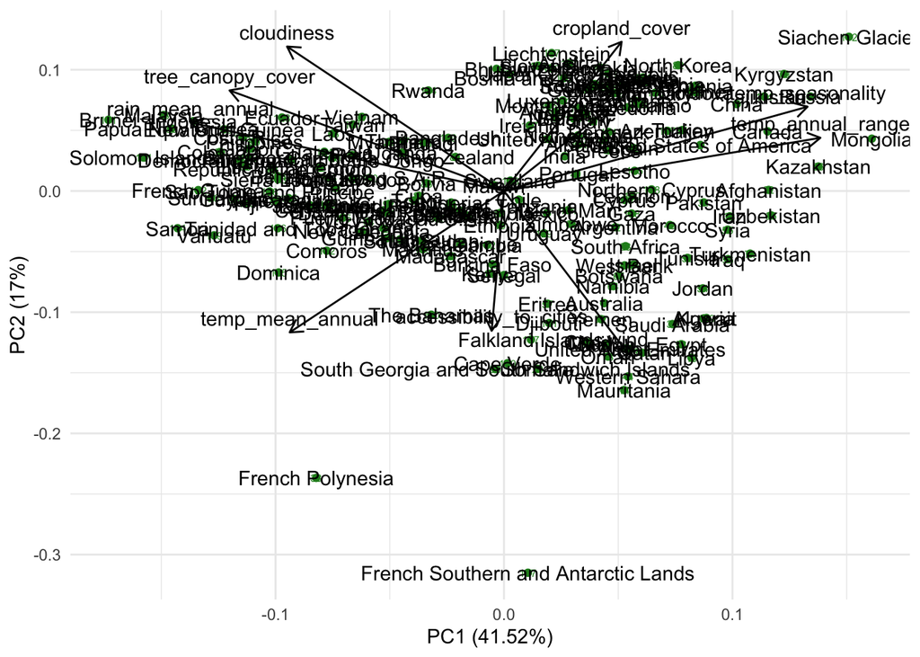

```r
## PCA Bi Plot
autoplot(env_pca,
         data = climate_subset,
         loadings = TRUE,
         label = TRUE,
         colour = "forestgreen",
         loadings.label = TRUE,
         label.size = 2,
         loadings.colour= "black",
         loadings.label.colour = "black",
         loadings.label.vjust = -0.5) +
  theme_minimal() +
  geom_text(aes(label = country)) +
  theme(legend.position = "none")
```

**Figure 1.** Biplot with principal component analysis results. Each point represents a country (n=188). The length of each line indicates the variance in the principal component direction.

Closer poinra are more similar overall in mutlivariate space

### Summary

Longer lines indicate larger variance. - temperature seasonality and annual temperature range are correlated variables and have a large variance drive by PC1 -

Major Take aways